# Challenge 6: Basic Principles of Data-Driven Story-telling

Author

Published

**Make sure you change the author’s name in the above YAML header.**

## Challenge Overview

In this challenge, we will mainly apply the principles we learned from Jane Miller’s book in practice. You will review multiple examples of data description and presentation in text, table/number, and charts/figures. Please read the instructions for each part and complete your challenges.

**For all the screenshots, images, or tables mentioned in the questions, please see the challenge6_f24_instructions.html file. You don’t need to include any of these items in your rendered challenge file.**

## Part 1. Simple Applications

1. **Recall Jane Miller’s Ws mentioned in Chapter #2. One of the W’s (Who, What, When, and Where, Why) is missing from each of the following table descriptions. Rewrite each sentence to include that information. (1 pt)**

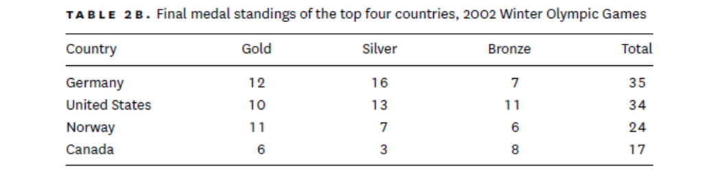

   1. “Germany did the best at the 2002 Winter Olympics, with 35 medals, compared to 34 for the United States, 24 for Norway, and 17 for Canada.”
   2. “Gold, silver, and bronze medals each accounted for about one-third of the medal total.”
   3. “At the 2002 Winter Olympics, the United States won more medals than all other countries, followed by Canada, Germany, and Norway.”
2. **For each of the following situations, specify whether you would use prose of text, a table of numbers, or a particular type of chart/figure. Explain why you chose this way to present the data. (1 pt)**
   1. Statistics on five types of air pollutants in the 10 largest US cities for a government report
   2. Trends in the value of three stock market indices over one year for a web page
   3. Notification to other employees in your corporation of a change in shipping fees
   4. Distribution of voter preferences for grade-level composition of a new middle school (grades 5–8, grades 6–8, or grades 6–9) for a presentation at a local school board meeting
   5. National estimates of the number of uninsured among part-time and full-time workers for an introductory section of an article analyzing effects of employment on insurance coverage in New York City
3. **Read the sentences below. What additional information would someone need in order to answer the associated question? (1 pt)**
   1. “Brand X costs twice as much as Brand Q. Can I afford Brand X?”
   2. “My uncle is 6’6” tall? Will he fit in my new car?”
   3. “New Diet Limelite has 25% fewer calories than Diet Fizzjuice. How much faster will I lose weight on Diet Limelite?”
   4. “It has been above 25 degrees every day. We’re really having a warm month, aren’t we?”
4. **Indicate whether each of the following sentences correctly reflects table 4B. If not, rewrite the sentence so that it is correct. Check both the correctness and completeness of these sentences. (1 pt)**

   Note: According to [Wikipedia](https://en.wikipedia.org/wiki/Voter_turnout), ” In political science, voter turnout is the participation rate (often defined as those who cast a ballot) of a given election. This is typically the percentage of registered, eligible, or all voting-age people.”

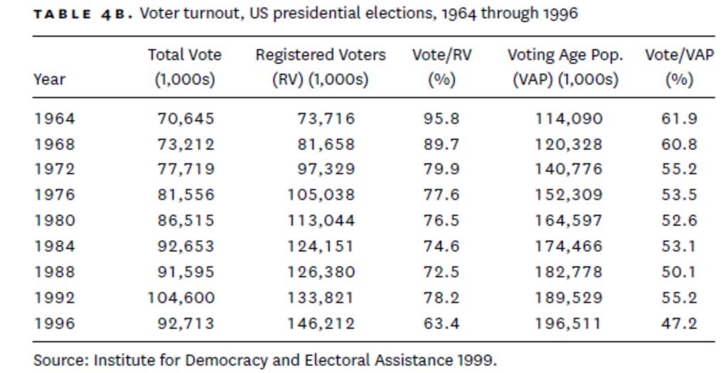

   1. Between 1964 and 1996, there was a steady decline in voter participation.
   2. Voter turnout was better in 1996 (63.4%) than in 1964 (61.9%).
   3. The majority of all registered voters participated in the 1964 US presidential election.
   4. The best year for voter turnout was 1992, with 104,600 people voting.
   5. A higher percentage of the voting-age population was registered to vote in 1996 than in 1964.
5. **Identify terms that need to be defined or restated for a non-technical audience without much knowledge about the topic or statistical method. You don’t need to explain these terms (you don’t need to know any of the statistical methods mentioned).** **Just identify them. (1 pt)**

   a. “According to the latest study based on the [VDem Dataset](https://v-dem.net/data/the-v-dem-dataset/), the average Rule of Law score is statistically higher in democratic countries than non-democratic countries based on a t-test (p = 0.01).”

   b. ” According to the logistic regression results in the screenshot below, we can see a positive correlation between household income and the vote choice for G.W. Bush, with a positive coefficient (log-odd = 0.33). ”

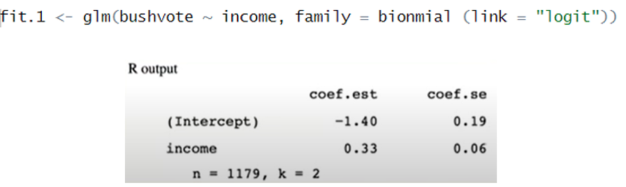

## Part 2. Practical Applications

1. **Suppose you work as a data analyst in the music-producing industry. One day, you get a data report that studies the popularity of different genres of music. The following scatter plot is presented to you. There is no text description for either this table or the data. (2.5 pts)**

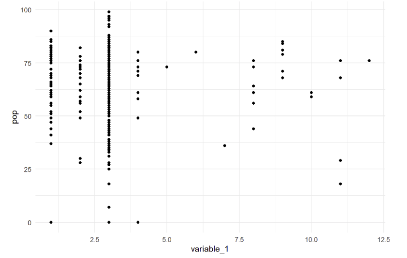

   (1) What information can you describe or summarize based on the current graph? (1 pt)

   (2) Thinking of the principles we learned in the week of visualization customization and Jane Miller’s principles. What additional information (Please describe at least three things [at least one thing that is NOT about graph customization, such as title, color, label, etc.] that you consider adding to this table so that it can convey meaningful information. (1.5 points)

   (For your reference, this is the original source of the dataset: https://www.kaggle.com/datasets/leonardopena/top-spotify-songs-from-20102019-by-year)
2. **Two articles on scientific studies talk about the “risks.” Please read the titles and quotes from these two articles and answer the following two questions. (2.5)**

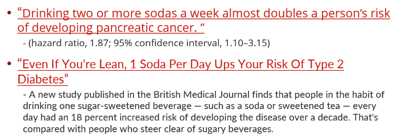

   (1) Given the information provided, in which case is there a greater “risk”: the Pancreatic Cancer case or the Diabetes case?

   (2) Think of Jane Miller’s principles. What additional information would you need to know to compare the “risk” in the two cases?